# Political Leaning in Correlation with COVID-19 Outcomes

### Chart 2

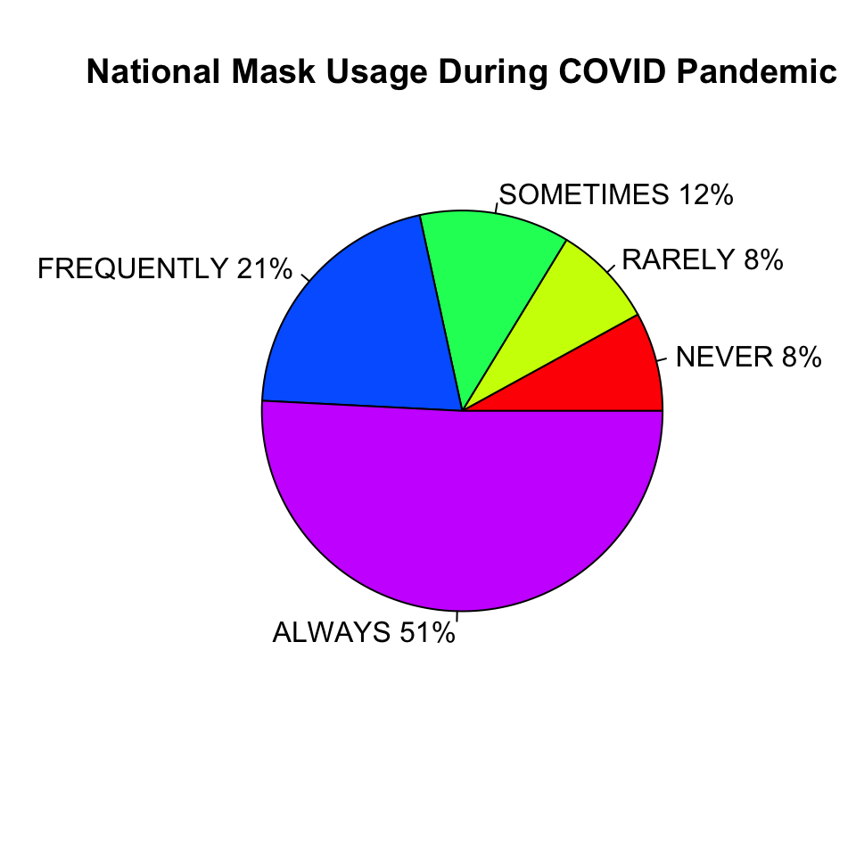

The use of these graphs is to calculate the mask usage proportions in the US by people’s frequency of wearing masks from never, rarely, sometimes, frequently and always. Survey results were averaged and compiled into their respective categories. Roughly 72% of people wore a mask frequently or always during the COVID-19 pandemic.

### Chart 3

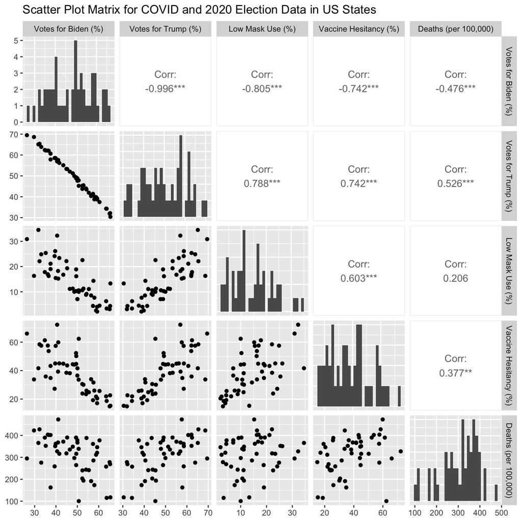

The scatter plot matrix above depicts all the correlations between variables relating to COVID-19 and the 2020 US elections. Each point represents a state. When the percentage of votes for Biden and Trump were plotted against COVID deaths per 100,000, there was a negative correlation with Biden and a positive correlation with Trump. Several similar trends could be noticed with mask usage and vaccine hesitancy. Additionally, vaccine hesitancy and low mask usage both had positive correlations with deaths per 100,000. This is indicative of how rhetoric from the 2020 presidential candidates influenced people to react differently. The scatter plot matrix depicts how states that Trump won with larger margins had less mask usage and increase vaccine hesitancy. Consequently, higher death rates of COVID were reported in those states.